# Machine Learning Assignment

Geoff Williams

Thursday, January 28, 2016

## Overview

In this paper we’ll be looking at the data set produced by Ugulino, W.; Cardador, D.; Vega, K.; Velloso, E.; Milidiu, R.; Fuks, H. in respect Fitness bands and predicting if a person was doing a dumbbell bicep curl correctly. The intent is to generate a model predicting whether the person was performing the correct arm action or one of 4 other common mistakes. To be successful, we will need to achieve an accuracy of 99% or better when predicting the action (this will be referred to as ‘class’) from the data.

## Data cleansing

When we first look at the data we first that there are some initial columns reflecting things such as the row number, the person wearing the fitness band and time information. While these could be important in other models, we’re attempting to predict class based on a single set of measurements regardless of who wore the band or point in time, so we’ll filter these out

```r
df<-df[,-(1:7)]
```

There are also columns with lots of blank character values and divide by zero errors. So we’ll change these to NA.

```r
df[df==""]<-NA
df[df=="#DIV/0!"]<-NA
```

Also we’ll now drop columns that have more than 80% NA values as these add virtually no information. All the remaining columns are measurements so should be numeric. Some have been read in as character so we’ll also convert these columns to numeric

```r
#save and drop the class values while we filter columns
classe<-as.factor(df$classe)
df<-df[,-153]

# Find the columns with columns shown as characters and convert them
for(i in colnames(df)) {
    if (typeof(df[,i])=="character") df[,i]<-as.numeric(df[,i])
}

#find the sum of NA in each column and drop the ones for which are 80% or more NA
na_count<-apply(df,2,function(x) sum(is.na(x)))
na_count<-as.data.frame(na_count)
cutoff<-0.8*nrow(df)
drops<-vector()
for(i in colnames(df)) {
    if(na_count[i,1]>cutoff) drops<-c(drops,i)
}
df<-df[,!(names(df) %in% drops)]

#Restore the class column
df$classe<-classe
```

The result is we now have 52 fairly clean columns we can use as predictors

## Exploration

While there are two many predictors to show with any clarity in one view, two are shown based here that show a clear predictor for whether the class was A or something else (A being correct action and B,C,D,E being incorrect action)

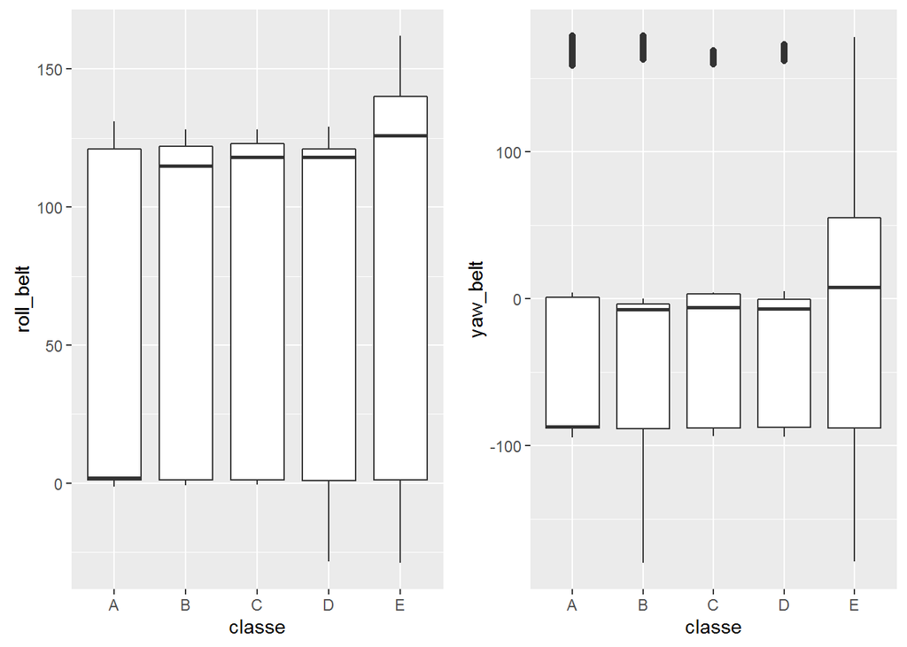

So we can see just for these two predictors, there is a strong indicator the median of each could be used for predicting A or non-A. For other predictors (not shown for brevity), further breakdown can be seen in the medians breaking down specific classes

## Modeling

To model this several decisions were made specifically:

- We will try three methods (again for brevity) and pick the best. To enable this, we will split the supplied training set into two sets -> a training (70%) and test set(30%). Validation of the final result will be done with a separately supplied test set
- K-Fold cross validation will be used. as the sample set is relatively large, a larger K value will be used (reduces biases and increases variability)

```r
inTrain<-createDataPartition(y=df$classe,p=0.7,list=FALSE)
training<-df[inTrain,]
testing<-df[-inTrain,]
```

### Rpart method (tree classification)

```r
modFitRP<-train(training$classe~.,method="rpart",data=training,trControl = trainControl(method="cv",number=10))
confusionMatrix(testing$classe, predict(modFitRP,testing))$overall
```

```
##       Accuracy          Kappa  AccuracyLower  AccuracyUpper   AccuracyNull
##      0.4978760      0.3439580      0.4850203      0.5107337      0.5167375
## AccuracyPValue  McnemarPValue
##      0.9981799            NaN
```

As can be seen the accuracy when run against the test set was quite low hitting less than 50%

### Random forest method

```r
modFitRF<-train(training$classe~.,method="rf",data=training,trControl = trainControl(method="cv",number=10))
confusionMatrix(testing$classe, predict(modFitRF,testing))$overall
```

```
##       Accuracy          Kappa  AccuracyLower  AccuracyUpper   AccuracyNull
##      0.9920136      0.9898964      0.9893938      0.9941262      0.2856415
## AccuracyPValue  McnemarPValue
##      0.0000000            NaN
```

This has a much better accuracy hitting the 99% accuracy we’re aiming for.

### Boosting method

```r
modFitGBM<-train(training$classe~.,method="gbm",data=training,trControl = trainControl(method="cv",number=10),verbose=FALSE)
confusionMatrix(testing$classe, predict(modFitGBM,testing))$overall
```

```
##       Accuracy          Kappa  AccuracyLower  AccuracyUpper   AccuracyNull
##      0.9627867      0.9529239      0.9576308      0.9674771      0.2854715
## AccuracyPValue  McnemarPValue
##      0.0000000            NaN
```

As can be seen this method is quite good but slightly under performs compared to the random forest method

So based on this, the Random forest will be the selected model

## Predictors of the chosen model

If we look at how many predictors actually were of importance we can see

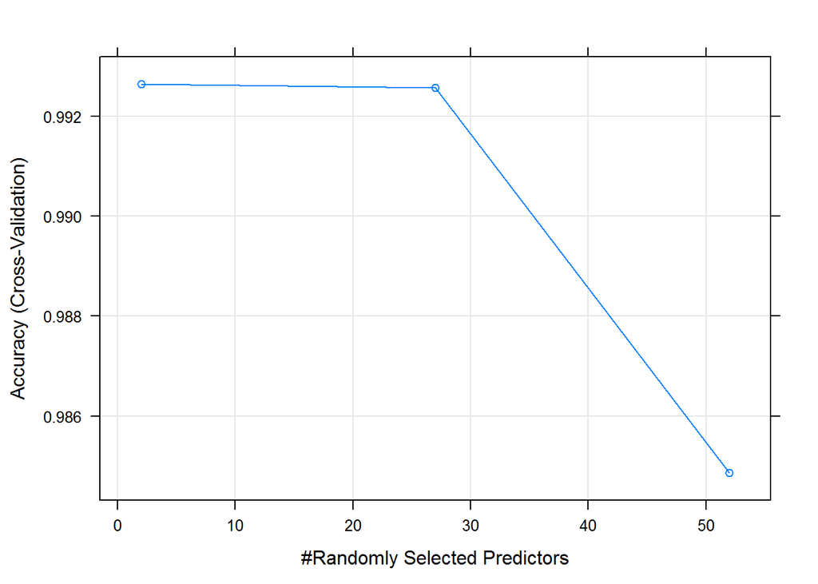

```r
plot(modFitRF)
```

This shows that of the 52 predictors only about 28 had significant effect and the rest adding little information

```r
varImp(modFitRF)
```

```
## rf variable importance
##
##   only 20 most important variables shown (out of 52)
##
##                   Overall
## roll_belt          100.00
## yaw_belt            86.06
## magnet_dumbbell_z   75.28
## pitch_forearm       72.52
## magnet_dumbbell_y   71.84
## pitch_belt          67.98
## roll_forearm        59.23
## magnet_dumbbell_x   56.46
## accel_belt_z        49.11
## accel_dumbbell_y    46.42
## magnet_belt_z       45.96
## magnet_belt_y       45.84
## roll_dumbbell       45.80
## roll_arm            39.22
## accel_forearm_x     37.48
## accel_dumbbell_z    37.39
## yaw_dumbbell        33.74
## gyros_belt_z        33.49
## accel_dumbbell_x    31.40
## magnet_forearm_z    30.74
```

As shown earlier the first two predictors added most of information in predicting A or non-A with the remaining 26 or so predictors supplying the information about the difference in B,C,D & E

Finally if we look at the estimate of the out-of-sample error from the model based on our testing set we see its less than 1% (quite low)

```r
pred<-predict(modFitRF,testing)
sum(testing$classe!=pred)/nrow(testing)
```

```
## [1] 0.00815633
```

## Evaluation again the validation data

There were 20 cases in the validation data, the model fitted them all correctly